# Bitácora-final

Authors

Daniela Prado Vargas - C26070

Erika Wu Liang - C38600

Adonis Araya Cascante - C4C517

Gabriel Chaves Esquivel - C4E273

# Carga de librerías y dataset

```r
library(tidyverse)
library(readxl)
paleta <- c("#1F3A61", "#3A6A8D", "#5CB4D1", "#F6DF60", "#FAA700")

Datos<-read_excel("../data/datos_diplomas_sector_estatal_2024.xlsx")

Datos <- Datos %>%
  mutate(
    ABREVIACIÓN = case_when(
      UNIVERSIDAD == "Universidad de Costa Rica" ~ "UCR",
      UNIVERSIDAD == "Universidad Nacional" ~ "UNA",
      UNIVERSIDAD == "Tecnológico de Costa Rica" ~ "TEC",
      UNIVERSIDAD == "Universidad Estatal a Distancia" ~ "UNED",
      UNIVERSIDAD == "Universidad Técnica Nacional" ~ "UTN",
      TRUE~"Otra"
    )
  )
table(Datos$ABREVIACIÓN)
```

```
 TEC  UCR  UNA UNED  UTN
1920 6333 4234 5208 2761
```

```r
view(Datos)
```

# Bitácora 1

## Pregunta:

¿Qué factores académicos, socio-demográficos y territoriales influyen en que los estudiantes matriculados en universidades estatales de Costa Rica logren graduarse, y cómo varían las tasas de graduación entre áreas de conocimiento, regiones y características del estudiantado?

## Objeto de estudio:

El objeto de estudio son los estudiantes de las universidades estatales de Costa Rica, analizados a partir de su proceso de matrícula y posterior graduación, considerando variables académicas (área de conocimiento, nivel académico, disciplina), socio-demográficas (sexo, edad, nacionalidad) y territoriales (provincia, cantón, zona urbano-rural, región de planificación). El interés está en comprender las relaciones, brechas y patrones entre quienes ingresan al sistema de educación superior estatal y quienes logran culminar sus estudios con éxito.

## Teorías

- **Teoría del Capital Humano (Becker, 1964)**  
  Plantea que la educación es una inversión que incrementa las habilidades y productividad de los individuos, lo cual justifica analizar las tasas de graduación como un indicador del retorno social y económico de las universidades estatales.

  https://www.camafu.org.mx/el-capital-humano/
- **Teoría de la Deserción Universitaria (Tinto, 1975; 1993)**  
  Explica la permanencia o abandono de los estudiantes a partir de factores académicos, sociales y personales. Fundamenta el análisis de brechas entre matrícula y graduación, considerando variables como región, género y área académica.

  https://steve.psy.gla.ac.uk/localed/tinto.html
- **Teoría de la Equidad en la Educación (Bourdieu & Passeron, 1970)**  
  Sostiene que el acceso y éxito en la educación superior están mediados por el capital cultural, económico y social de los estudiantes. Esta teoría apoya el análisis de desigualdades territoriales y socio-demográficas en las universidades estatales.

  https://archivo.revistas.ucr.ac.cr//index.php/sociales/article/view/49239

# Bitácora 2

## 1. Identificación de los elementos del conjunto de datos

### a. Características de los datos

Tipo de dato

```r
tipos <- tibble(
  columna = names(Datos),
  tipo = sapply(Datos, class)
)
print(tipos)
```

```
# A tibble: 25 × 2
   columna                   tipo
   <chr>                     <chr>
 1 AÑO                       numeric
 2 SECTOR_UNIVERSITARIO      character
 3 UNIVERSIDAD               character
 4 GAM_SEDE                  character
 5 SEDE_CONARE               character
 6 REGION_PLANIFICACION_SEDE character
 7 CARRERA                   character
 8 GRADO_ACADEMICO           character
 9 NIVEL_ACADEMICO           character
10 AREA_CONOCIMIENTO         character
# ℹ 15 more rows
```

### b. Población de estudio

Todas las personas a las que se les otorgó el título universitario durante el año 2024 y que hayan completado sus estudios académicos en alguna de las universidades públicas alrededor del país. Estos datos rondan entre personas de 19 a 76 años de edad.

### c. Muestra observada

La muestra observada es toda persona que se haya graduado durante el transcurso del año 2024 en alguna de las universidades públicas del país y que haya conseguido su título, independientemente de su nivel académico.

### d. Unidad estadística o individuos

Cada diploma dado a una persona que estudió en el sector estatal y completó sus estudios fielmente acorde al sistema educativo costarricense a lo largo del 2024.

### e. Variables de estudio

En esta sección se mostrarán las variables de estudio y qué representa cada una de ellas en la tabla de datos acorde a [OPES-CONARE](https://www.conare.ac.cr/transparencia/datos-abiertos/):

- **Año:** Año de graduación del estudiante (sujeto a 2024).
- **Sector universitario:** Distinción que se hace entre las instituciones de educación superior; diferencia entre si es estatal o privada (sujeto a estatal).
- **Universidad:** Nombre de la institución de educación superior universitaria.
- **GAM sede:** Clasificación de la ubicación de las sedes, si se encuentran dentro o fuera del Gran Área Metropolitana. El Observatorio Urbano de la Gran Área Metropolitana, más conocido como la OUGAM, construyó esta clasificación a partir de la información disponible en su momento; adicionalmente, se verificaron 11 en base al Sistema Nacional de Información Territorial.
- **Sede universitaria:** Las sedes son núcleos universitarios, por medio de los cuales las universidades impulsan, coordinan y desarrollan programas en una región determinada de acuerdo con demandas y necesidades de desarrollo regional y nacional.
- **Región de planificación regional de la sede:** Clasificación geográfica del territorio nacional en regiones que realiza el Sistema Nacional de Planificación (SNP) y Política Económica (MIDEPLAN) de Costa Rica. En Conare, dicha clasificación se realiza según la ubicación de la sede universitaria.
- **Carrera universitaria:** Conjunto de actividades y cursos ofrecidos por una institución superior en un determinado campo de conocimientos, el cual ha sido organizado por medio de un plan de estudios y que conduce a la obtención de un grado académico.
- **Grado académico:** Es el elemento del diploma que designa el valor académico de los conocimientos y habilidades del individuo dentro de una escala creada por las instituciones de educación superior, para indicar la profundidad y amplitud de esos conocimientos y habilidades en cuanto estos puedan ser garantizados por el diploma.
- **Nivel académico:** Agrupación de distintos grados académicos, de acuerdo con la profundidad y amplitud de los conocimientos.
- **Área del conocimiento (según clasificación Conare):** Agrupación de disciplinas con cierto grado de afinidad, según la clasificación realizada por las divisiones de Planificación Interuniversitaria y Académica de la OPES-Conare.
- **Disciplina (según clasificación Conare):** Es la agrupación de carreras académicas que, por su afinidad, son susceptibles de agruparse en una misma disciplina según su contenido y el mercado laboral.
- **Área UNESCO:** Organización de los programas educativos y las cualificaciones correspondientes por niveles y ámbitos de educación, según la clasificación de la UNESCO.
- **Disciplina UNESCO:** Agrupación de carreras académicas que, por su afinidad, son susceptibles de agruparse en una misma disciplina, según la clasificación de la UNESCO.
- **Clasificación STEM:** Clasificación utilizada por el Ministerio de Ciencia, Tecnología y Telecomunicaciones de Costa Rica (MICITT), que se utiliza para agrupar a las cuatro grandes áreas de conocimiento en las que trabajan científicos e ingenieros. El término STEM es el acrónimo de los términos en inglés Science, Technology, Engineering and Mathematics (Ciencia, Tecnología, Ingeniería y Matemáticas). La carrera que cursa el estudiante se clasifica según esta definición.
- **Sexo:** Es una variable biológica y genética que divide a los seres humanos en dos posibilidades solamente.
- **Edad:** Años transcurridos desde el nacimiento de la persona hasta el año de registro de la graduación.
- **Provincia de procedencia del graduado:** Nombre de la provincia en la que indicó el graduado habitar. Según el Decreto Ejecutivo N.° 40184-MGP, División Territorial Administrativa de la República de Costa Rica.
- **Cantón de procedencia del graduado:** Es el nombre del cantón en el que indicó el graduado habitar. La distribución de cantones y distritos de Costa Rica se establece por el Decreto Ejecutivo N.° 40184-MGP del 9 de enero de 2017, en la publicación de la División Territorial Administrativa de Costa Rica. Adicionalmente, se actualiza la base División Territorial Administrativa, 2022 del Sistema Nacional de Información Territorial (SNIT).
- **Zona de urbanización del graduado:** Es una clasificación geográfica del territorio nacional que utiliza un índice elaborado por el Instituto Nacional de Estadística y Censos (INEC), que está relacionado al grado de urbanización en cuatro categorías, según el distrito de procedencia del graduado.
- **Zona urbano-rural de procedencia del graduado:** Es una clasificación geográfica del territorio nacional en dos grandes categorías, basada en el Censo Nacional de Población y Vivienda (2011) del Instituto Nacional de Estadística y Censos (INEC), según el distrito de procedencia del graduado.
- **Región de planificación de procedencia del graduado:** Es la clasificación geográfica del territorio nacional en regiones que realiza el Sistema Nacional de Planificación (SNP) del Ministerio de Planificación Nacional y Política Económica (MIDEPLAN) de Costa Rica. En Conare, dicha clasificación se realiza según la ubicación de procedencia del graduado.
- **Clasificación de GAM y no GAM del estudiante:** Se clasifica la ubicación de las sedes, si se encuentran dentro o fuera del Gran Área Metropolitana. Esta clasificación se construyó a partir de la información que tenía disponible en su momento el Observatorio Urbano de la Gran Área Metropolitana (OUGAM); adicionalmente, se verificaron 11 en base al Sistema Nacional de Información Territorial.
- **Condición de nacionalidad del graduado:** Describe la condición de nacionalidad del graduado, según el país de procedencia reportado.
- **Continente de procedencia del graduado:** En función del país reportado por el graduado, se asocia éste al continente respectivo.

## 2. Visualización inicial de los datos

```r
print(head(Datos, 5))
```

```
# A tibble: 5 × 25
    AÑO SECTOR_UNIVERSITARIO UNIVERSIDAD               GAM_SEDE SEDE_CONARE
  <dbl> <chr>                <chr>                     <chr>    <chr>
1  2024 Sector Estatal       Universidad de Costa Rica GAM      Ciudad Universi…
2  2024 Sector Estatal       Universidad de Costa Rica GAM      Ciudad Universi…
3  2024 Sector Estatal       Universidad de Costa Rica GAM      Ciudad Universi…
4  2024 Sector Estatal       Universidad de Costa Rica GAM      Ciudad Universi…
5  2024 Sector Estatal       Universidad de Costa Rica GAM      Ciudad Universi…
# ℹ 20 more variables: REGION_PLANIFICACION_SEDE <chr>, CARRERA <chr>,
#   GRADO_ACADEMICO <chr>, NIVEL_ACADEMICO <chr>, AREA_CONOCIMIENTO <chr>,
#   DISCIPLINA <chr>, AREA_UNESCO <chr>, DISCIPLINA_UNESCO <chr>,
#   STEM_MICITT <chr>, SEXO <chr>, EDAD <dbl>, PROVINCIA_GRADUADO <chr>,
#   CANTON_GRADUADO <chr>, `ZONA_DE URBANIZACION_GRADUADO` <chr>,
#   ZONA_URBANO_RURAL_GRADUADO <chr>, REGION_PLANIFICACION_GRADUADO <chr>,
#   GAM_ESTUDIANTE <chr>, TIPO_NACIONALIDAD <chr>, CONTINENTE <chr>, …
```

## 3. Resumen estadístico de las variables cuantitativas

```r
resumen <- summary(Datos[sapply(Datos, is.numeric)])
print(resumen)
```

```
      AÑO            EDAD
 Min.   :2024   Min.   :19.00
 1st Qu.:2024   1st Qu.:24.00
 Median :2024   Median :26.00
 Mean   :2024   Mean   :28.49
 3rd Qu.:2024   3rd Qu.:31.00
 Max.   :2024   Max.   :76.00
```

Los datos muestran que todos los registros corresponden al año 2024 y que la mayoría de los graduados son adultos jóvenes. La edad mínima es de 19 y la máxima de 76, con una media de 28.49 años y una mediana de 26, lo que indica una ligera tendencia hacia edades mayores debido a algunos casos más altos.

## 4. Distribución de las variables cuantitativas

### Distribución por edad

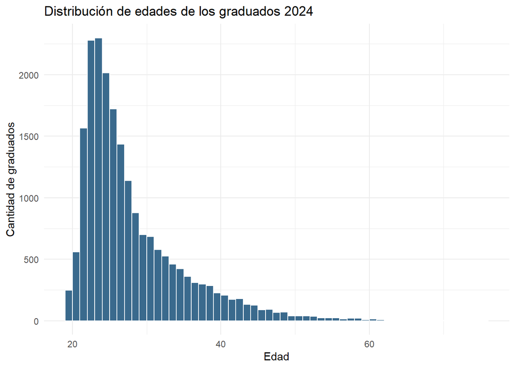

```r
ggplot(data = Datos, aes(x = EDAD)) +
  geom_histogram(
    binwidth = 1,
    boundary = 19,
    fill = paleta[2],
    color = "white"
  ) +
  labs(
    title = "Distribución de edades de los graduados 2024",
    x = "Edad",
    y = "Cantidad de graduados"
  ) +
  theme_minimal()
```

## 5. Relación entre las variables

### Comparación académica

#### Top 10 de carreras con más graduados

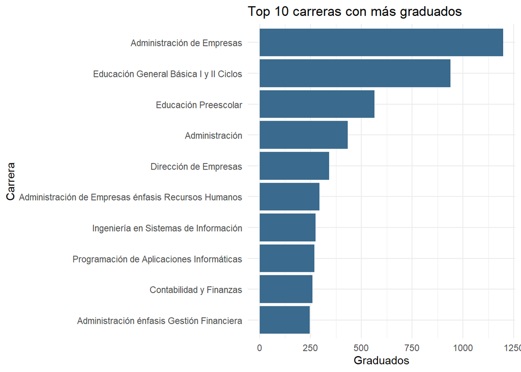

```r
# Distribución de graduados por carrera
graduados_carrera <- Datos %>%
  group_by(CARRERA) %>%
  summarise(
    n_graduados = n(),
    proporcion = n() / nrow(Datos)
  ) %>%
  arrange(desc(n_graduados))

top10 <- graduados_carrera %>%
  arrange(desc(n_graduados)) %>%
  head(10)

ggplot(top10, aes(x = reorder(CARRERA, n_graduados),
                  y = n_graduados)) +
  geom_col(fill = paleta[2]) +
  coord_flip() +
  labs(title = "Top 10 carreras con más graduados",
       x = "Carrera",
       y = "Graduados") +
  theme_minimal()
```

El gráfico muestra los 10 carreras con mayor cantidad de graduados. Se observa que la carrera con mayor número de egresados es Administración de Empresas, con un poco menos de 1.250 graduados. Le sigue Educación General Básica del primer y segundo ciclo, con aproximadamente 900 egresados. La carrera con menor número de graduados, pero aún dentro del top, es Administración con énfasis en Gestión Financiera, con cerca de 250 graduados.

#### Proporción de graduados STEM

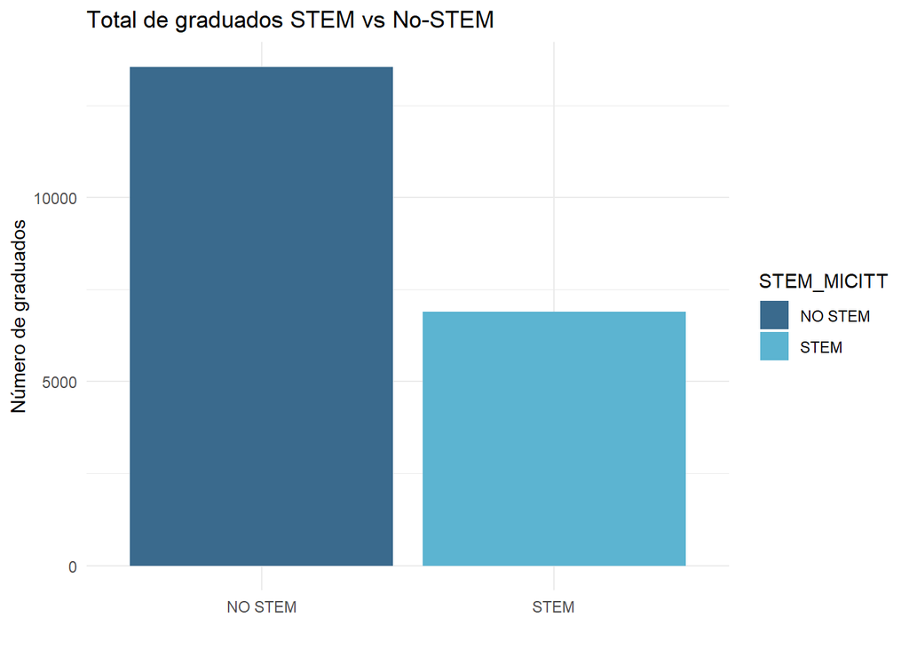

```r
# Distribución de graduados STEM vs No-STEM (totales)
stem_dist <- Datos %>%
  group_by(STEM_MICITT) %>%
  summarise(
    n = n()
  )

# Gráfico de barras por totales
ggplot(stem_dist, aes(x = STEM_MICITT, y = n, fill = STEM_MICITT)) +
  geom_col() +
  labs(title = "Total de graduados STEM vs No-STEM",
       x = "",
       y = "Número de graduados") +
  theme_minimal() +
  scale_fill_manual(values = paleta[2:3])
```

#### Relación entre sexo de los graduados y clasificación STEM

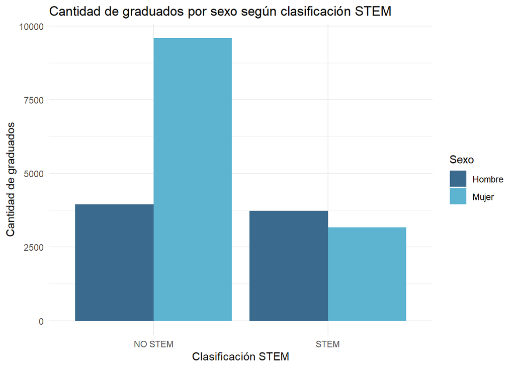

```r
ggplot(Datos, aes(x = STEM_MICITT, fill = SEXO)) +
  geom_bar(position = "dodge") +
  scale_fill_manual(values = paleta[2:3]) +
  labs(
    title = "Cantidad de graduados por sexo según clasificación STEM",
    x = "Clasificación STEM",
    y = "Cantidad de graduados",
    fill = "Sexo"
  ) +
  theme_minimal()
```

En el gráfico se observa que, en las carreras no STEM, la mayoría de las personas graduadas son mujeres, superando casi el doble de la cantidad de hombres graduados. En contraste, en las carreras STEM, aunque las cifras son más equilibradas, la cantidad de hombres graduados es mayor que la de mujeres.

#### Graduados por universidad según área de conocimiento

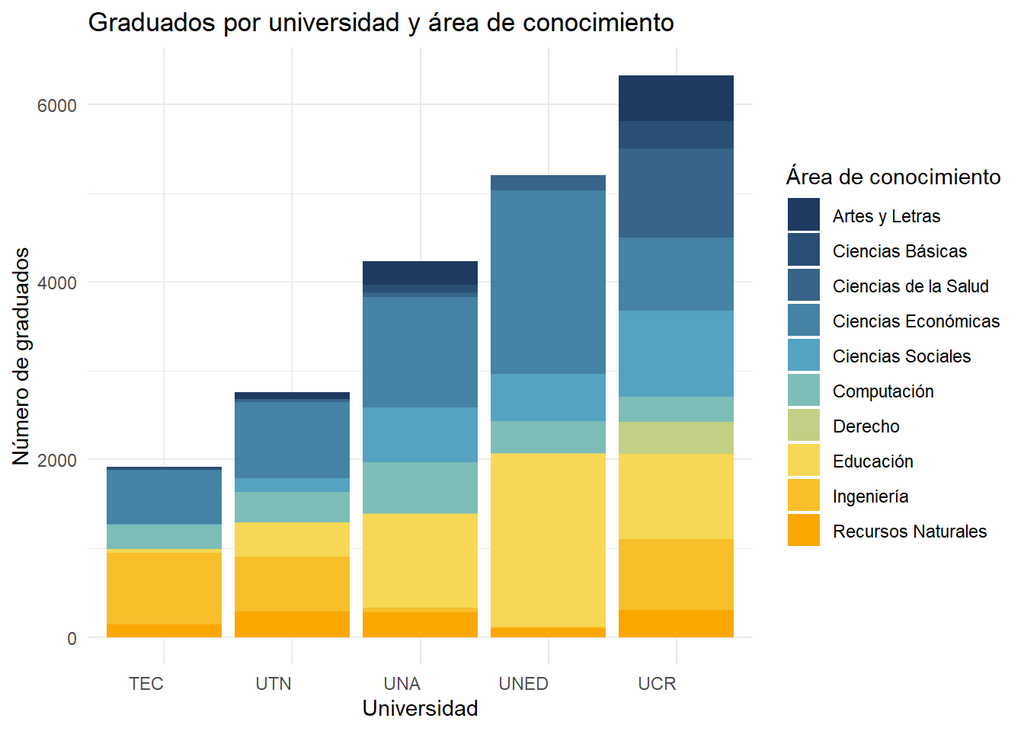

```r
uni_graduados <- Datos %>%
  group_by(ABREVIACIÓN) %>%
  summarise(
    n_graduados = n()
  ) %>%
  arrange(desc(n_graduados))

top10_universidades <- uni_graduados %>% head(10)

uni_area <- Datos %>%
  group_by(ABREVIACIÓN, AREA_CONOCIMIENTO) %>%
  summarise(n_graduados = n()) %>%
  ungroup()
paleta_expandida <- colorRampPalette(paleta)(length(unique(uni_area$AREA_CONOCIMIENTO)))
# Función que expande los colores de una paleta que tiene pocos colores y para el gráfico se necesitan más

ggplot(uni_area, aes(x = reorder(ABREVIACIÓN, n_graduados, sum),
                     y = n_graduados,
                     fill = AREA_CONOCIMIENTO)) +
  geom_col() +
  labs(title = "Graduados por universidad y área de conocimiento",
       x = "Universidad",
       y = "Número de graduados",
       fill = "Área de conocimiento") +
  theme_minimal() +
  theme(axis.text.x = element_text(hjust = 1)) +
  scale_fill_manual(values = paleta_expandida)
```

#### Comparación entre número de graduados por provincia y universidad

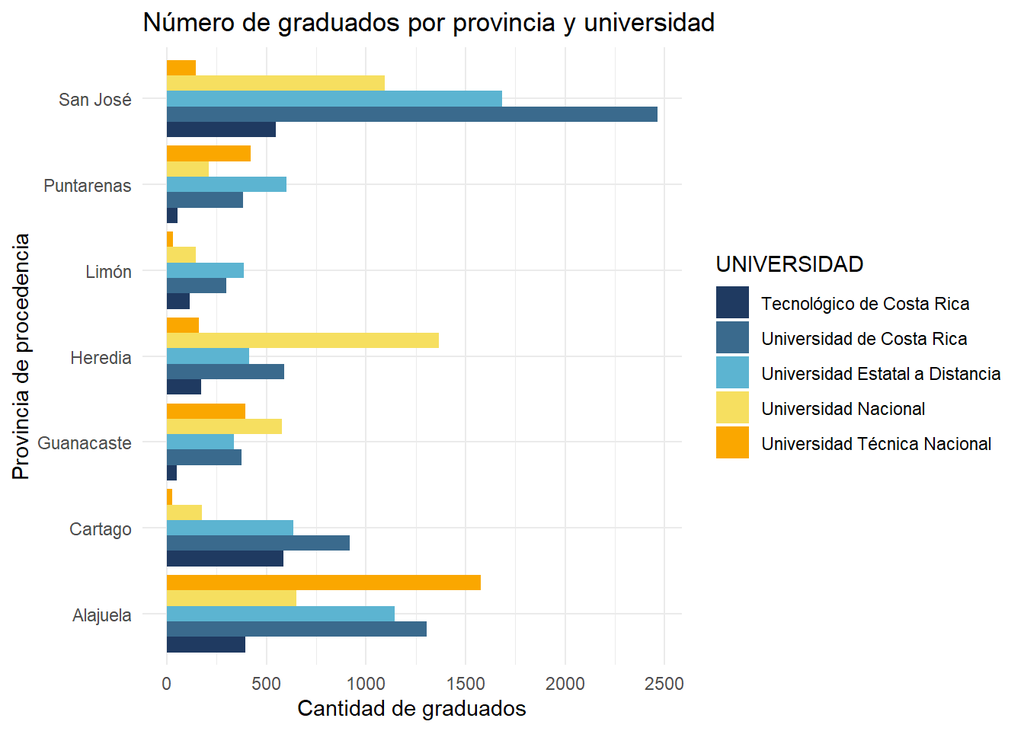

```r
Datos %>%
  mutate(
    PROVINCIA_GRADUADO = str_trim(PROVINCIA_GRADUADO),
    PROVINCIA_GRADUADO = str_to_title(PROVINCIA_GRADUADO)
  ) %>%
  filter(PROVINCIA_GRADUADO != "Extranjero") %>%
  ggplot(aes(x = PROVINCIA_GRADUADO, fill = UNIVERSIDAD)) +
  geom_bar(position = "dodge") +
  scale_fill_manual(values = paleta) +
  labs(
    title = "Número de graduados por provincia y universidad",
    x = "Provincia de procedencia",
    y = "Cantidad de graduados"
  ) +
  theme_minimal() +
  coord_flip() +
  theme(axis.text.y = element_text(angle = 0, hjust = 1))
```

Aquí podemos observar que existe un tipo de relación entre la cantidad de personas graduadas por provincia de nacimiento y la ubicación de la universidad en la que obtuvieron su título, especialmente dentro de la GAM. Se aprecia que en Alajuela la mayoría de graduados provienen de la UTN, ubicada en esa misma provincia. En Heredia predomina la UNA y en San José la UCR, también localizada ahí. La única excepción a este patrón es el TEC, ya que aunque se encuentra en Cartago, en dicha provincia la mayoría de graduados son de la UCR. Por otro lado, en las provincias fuera de la GAM se observa que en Limón y Puntarenas la mayoría de graduados pertenecen a la UNED, lo cual tiene sentido al ser una universidad con modalidad virtual, mientras que en Guanacaste predominan los graduados de la UNA.

### Comparación Territorial

#### Efecto de estudiar en GAM vs fuera de GAM

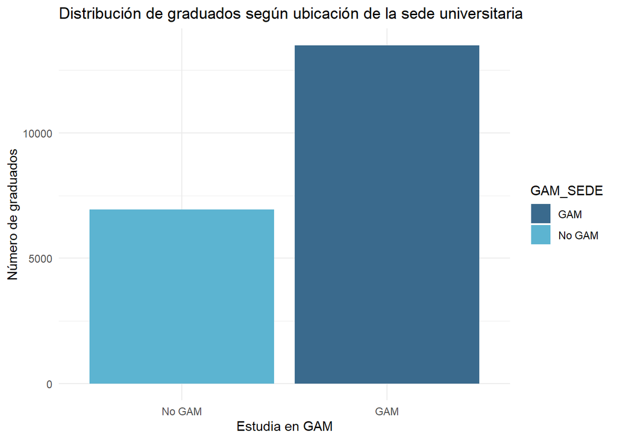

```r
# Distribución de graduados por GAM_SEDE
gam_sede_dist <- Datos %>%
  filter(!GAM_SEDE %in% c("Sin información", "No aplica")) %>%
  group_by(GAM_SEDE) %>%
  summarise(
    n = n()
  )

# Gráfico de barras
ggplot(gam_sede_dist, aes(x = reorder(GAM_SEDE, n), y = n, fill = GAM_SEDE)) +
  geom_col() +
  labs(
    title = "Distribución de graduados según ubicación de la sede universitaria",
    x = "Estudia en GAM",
    y = "Número de graduados"
  ) +
  theme_minimal() +
  scale_fill_manual(values = paleta[2:3])
```

El gráfico muestra la distribución de graduados según si estudian en la GAM o fuera de ella. Se observa que más de la mitad de los graduados provienen de universidades situadas en la GAM, mientras que el resto se gradúa en instituciones fuera de esta región. Esto refleja la concentración de estudiantes en la región metropolitana y su predominancia en el total de egresados.

#### Efecto de vivir en GAM vs fuera de GAM

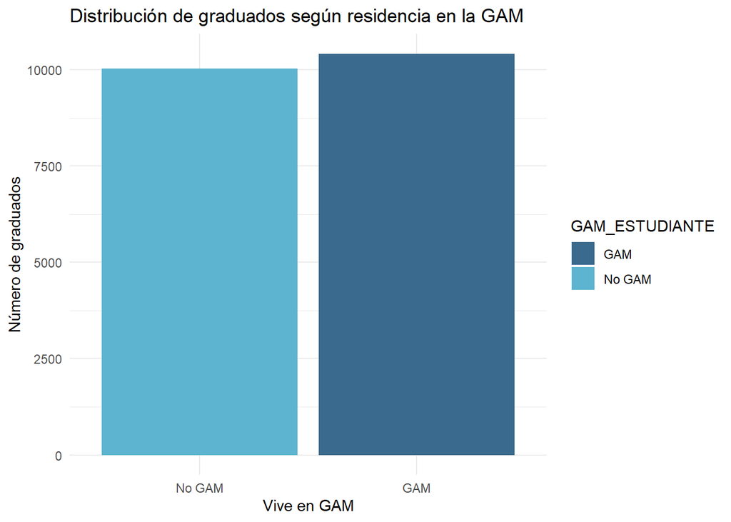

```r
# Distribución de graduados por GAM_ESTUDIANTE
gam_est_dist <- Datos %>%
  filter(!GAM_ESTUDIANTE %in% c("No aplica")) %>%
  group_by(GAM_ESTUDIANTE) %>%
  summarise(
    n = n()
  )

# Gráfico de barras
ggplot(gam_est_dist, aes(x = reorder(GAM_ESTUDIANTE, n), y = n, fill = GAM_ESTUDIANTE)) +
  geom_col() +
  labs(
    title = "Distribución de graduados según residencia en la GAM",
    x = "Vive en GAM",
    y = "Número de graduados"
  ) +
  theme_minimal() +
  scale_fill_manual(values = paleta[2:3])
```

#### Distribución de graduados según zona rural o urbana

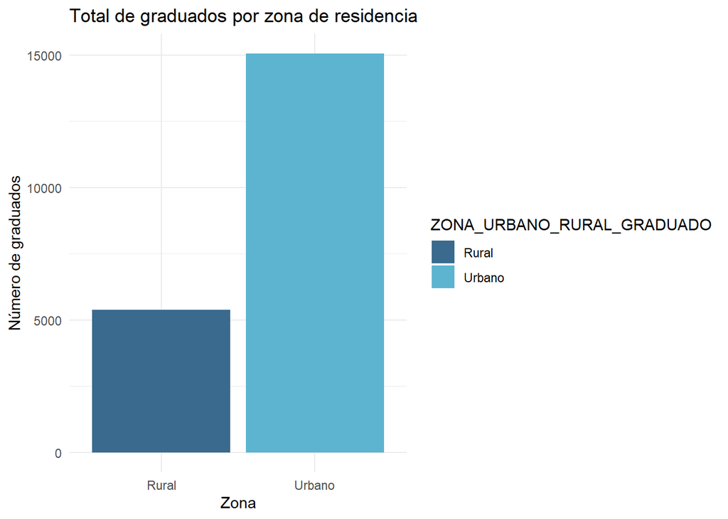

```r
# Totales de graduados por zona
zona_dist <- Datos %>%
  filter(!ZONA_URBANO_RURAL_GRADUADO %in% c("Sin información", "No aplica")) %>%
  group_by(ZONA_URBANO_RURAL_GRADUADO) %>%
  summarise(n = n()) %>%
  arrange(desc(n))

# Gráfico
ggplot(zona_dist, aes(x = reorder(ZONA_URBANO_RURAL_GRADUADO, n), y = n, fill = ZONA_URBANO_RURAL_GRADUADO)) +
  geom_col() +
  labs(
    title = "Total de graduados por zona de residencia",
    x = "Zona",
    y = "Número de graduados"
  ) +
  theme_minimal() +
  scale_fill_manual(values = paleta[2:3])
```

#### Distribución de graduados por sexo

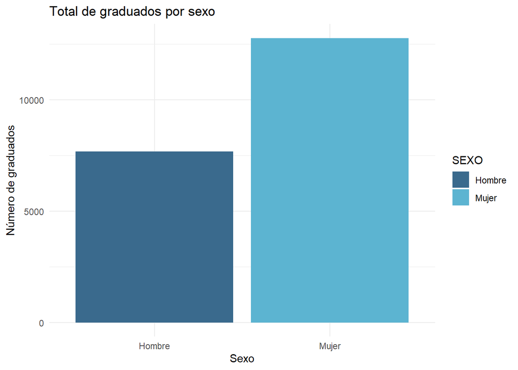

```r
# Distribución de graduados por sexo
sexo_dist <- Datos %>%
  group_by(SEXO) %>%
  summarise(
    n = n()
  )

# Gráfico de barras por sexo
ggplot(sexo_dist, aes(x = SEXO, y = n, fill = SEXO)) +
  geom_col() +
  labs(
    title = "Total de graduados por sexo",
    x = "Sexo",
    y = "Número de graduados"
  ) +
  theme_minimal() +
  scale_fill_manual(values = paleta[2:3])
```

El gráfico presenta el total de graduados por sexo. Se observa que la mayoría de los egresados son mujeres, mientras que los hombres representan un menor número del total.

#### Distribución por sexo y área de conocimiento

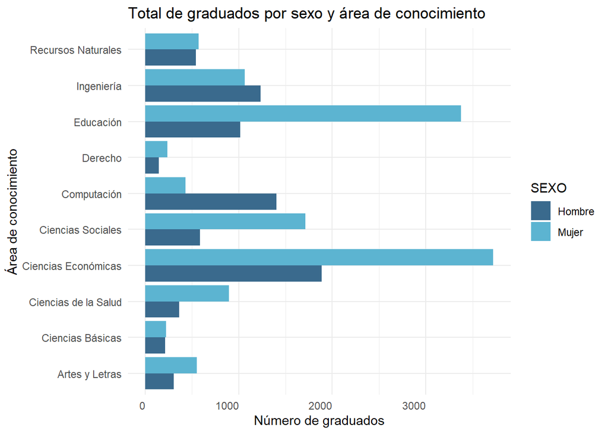

```r
# Distribución de graduados por sexo y área
sexo_area_dist <- Datos %>%
  group_by(AREA_CONOCIMIENTO, SEXO) %>%
  summarise(n = n()) %>%
  ungroup()
# Gráfico
ggplot(sexo_area_dist, aes(x = AREA_CONOCIMIENTO, y = n, fill = SEXO)) +
  geom_col(position = "dodge") +
  labs(
    title = "Total de graduados por sexo y área de conocimiento",
    x = "Área de conocimiento",
    y = "Número de graduados"
  ) +
  theme_minimal() +
  coord_flip() +
  theme(axis.text.x = element_text(hjust = 1)) +
  scale_fill_manual(values = paleta[2:3])
```

#### Distribución por edad

```r
# Crear grupo de edad
Datos <- Datos %>%
  mutate(
    GRUPO_EDAD = case_when(
      EDAD >= 17 & EDAD <= 20 ~ "17-20",
      EDAD >= 21 & EDAD <= 24 ~ "21-24",
      EDAD >= 25 & EDAD <= 29 ~ "25-29",
      EDAD >= 30              ~ "30+",
      TRUE ~ NA_character_
    )
  )

# Distribución de graduados por grupo de edad
edad_dist <- Datos %>%
  filter(!is.na(GRUPO_EDAD)) %>%
  group_by(GRUPO_EDAD) %>%
  summarise(n = n()) %>%
  arrange(desc(n))

print(edad_dist)
```

```
# A tibble: 4 × 2
  GRUPO_EDAD     n
  <chr>      <int>
1 25-29       7188
2 21-24       6704
3 30+         6316
4 17-20        248
```

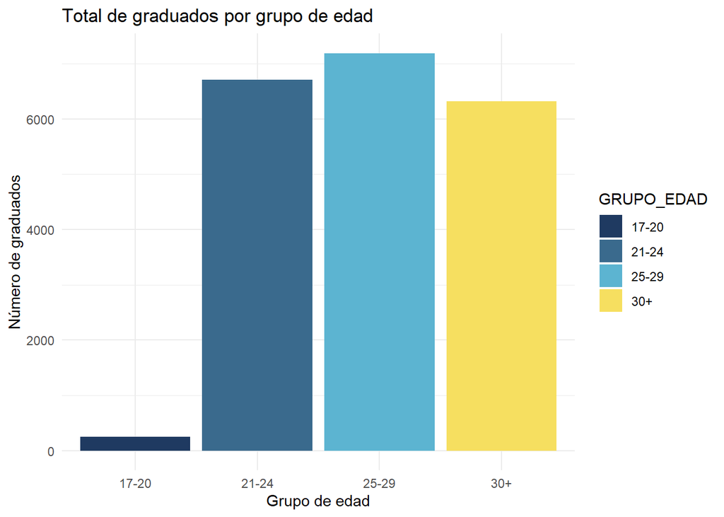

```r
# Gráfico de barras
ggplot(edad_dist, aes(x = GRUPO_EDAD, y = n, fill = GRUPO_EDAD)) +
  geom_col() +
  labs(
    title = "Total de graduados por grupo de edad",
    x = "Grupo de edad",
    y = "Número de graduados"
  ) +
  theme_minimal() +
  scale_fill_manual(values = paleta)
```

```r
# Estadísticos descriptivos
summary(Datos$EDAD)
```

```
   Min. 1st Qu.  Median    Mean 3rd Qu.    Max.
  19.00   24.00   26.00   28.49   31.00   76.00
```

El gráfico que muestra el total de graduados por grupo de edad evidencia que la mayor concentración de egresados se encuentra en el rango de 25 a 29 años, seguido por el grupo de 21 a 24 años. Los graduados mayores de 30 años ocupan un tercer lugar en cantidad, mientras que el grupo de 17 a 20 años es el menos representado, con muy pocas personas.

#### Migrantes vs Nacionales

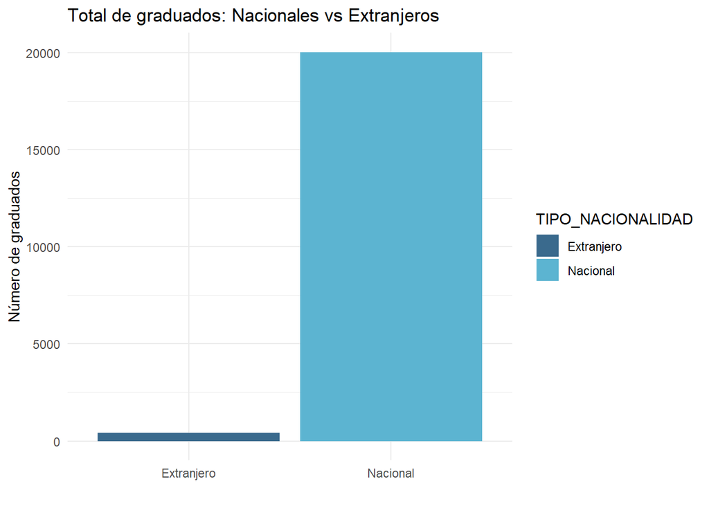

```r
# Totales por nacionalidad
nat_ext <- Datos %>%
  group_by(TIPO_NACIONALIDAD) %>%
  summarise(n = n())

# Gráfico
ggplot(nat_ext, aes(x = TIPO_NACIONALIDAD, y = n, fill = TIPO_NACIONALIDAD)) +
  geom_col() +
  labs(
    title = "Total de graduados: Nacionales vs Extranjeros",
    x = "",
    y = "Número de graduados"
  ) +
  theme_minimal() +
  scale_fill_manual(values = paleta[2:3])
```

El gráfico evidencia que la gran mayoría son nacionales, alcanzando casi los 20.000 egresados. En contraste, los graduados extranjeros son muy pocos, prácticamente cercanos a cero. Esto indica que la participación de estudiantes extranjeros en las universidades públicas de Costa Rica es mínima frente a la de los estudiantes nacionales.

#### Migrantes por universidad

```r
migrantes <- Datos %>%
  filter(TIPO_NACIONALIDAD != "Nacional") %>%   # Solo migrantes
  group_by(UNIVERSIDAD) %>%
  summarise(
    migrantes = n()
  ) %>%
  arrange(desc(migrantes))

print(migrantes)
```

```
# A tibble: 5 × 2
  UNIVERSIDAD                     migrantes
  <chr>                               <int>
1 Universidad Estatal a Distancia       116
2 Universidad de Costa Rica             108
3 Universidad Nacional                  106
4 Universidad Técnica Nacional           56
5 Tecnológico de Costa Rica              32
```

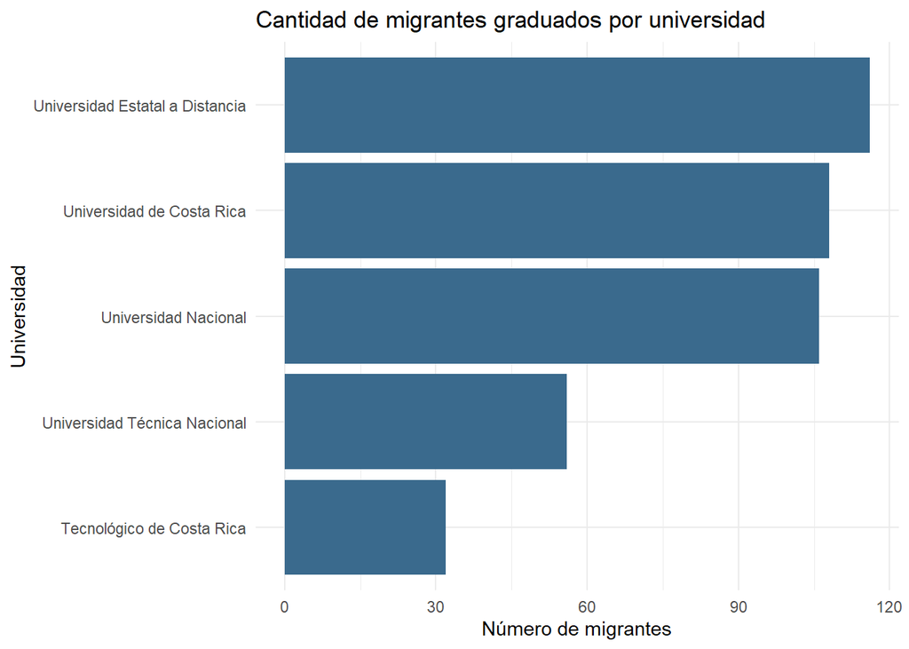

```r
ggplot(migrantes, aes(x = reorder(UNIVERSIDAD, migrantes), y = migrantes)) +
  geom_col(fill = paleta[2]) +
  coord_flip() +
  labs(
    title = "Cantidad de migrantes graduados por universidad",
    x = "Universidad",
    y = "Número de migrantes"
  ) +
  theme_minimal()
```

El gráfico evidencia que la Universidad Estatal a Distancia (UNED) concentra la mayor cantidad, con un poco menos de 120 personas. Le siguen la Universidad de Costa Rica (UCR) y la Universidad Nacional (UNA), con cifras muy similares, siendo ligeramente mayor la UCR. Posteriormente se ubica la Universidad Técnica Nacional (UTN), y finalmente el Tecnológico de Costa Rica (TEC), que presenta la menor cantidad de graduados migrantes.

## 6. Distribución de las variables categóricas

### Gráfico de distribución según universidad

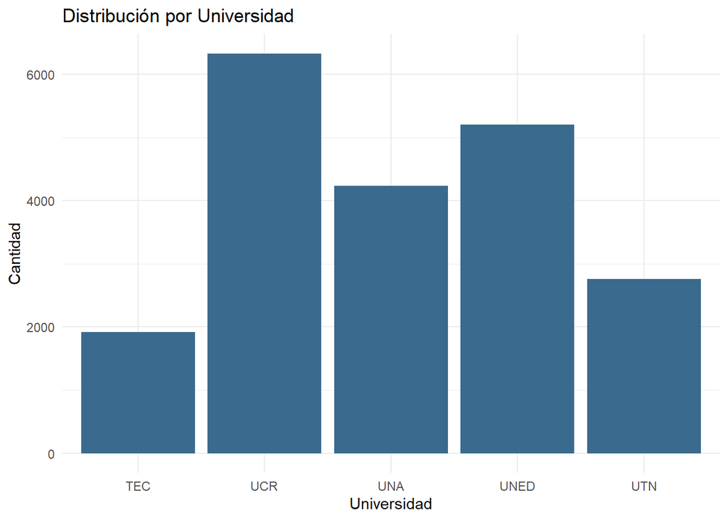

```r
Datos %>%
ggplot( aes(x = ABREVIACIÓN)) +
  geom_bar(fill = paleta[2]) +
  labs(
    title = "Distribución por Universidad",
    x = "Universidad",
    y = "Cantidad"
  ) +
  theme_minimal()
```

En este gráfico se observa que la mayor cantidad de personas graduadas proviene de la UCR, seguida por la UNED. En tercer lugar aparece la UNA, luego la UTN y, finalmente, el TEC.

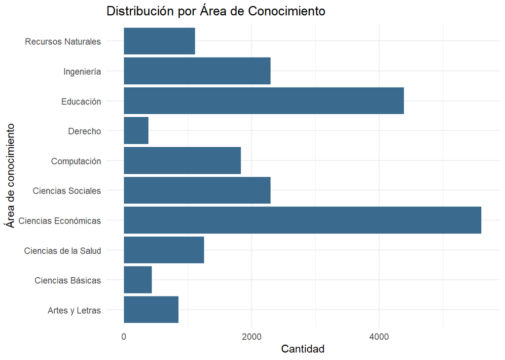

```r
Datos %>%
  ggplot(aes(x = AREA_CONOCIMIENTO)) +
  geom_bar(fill = paleta[2]) +
  labs(
    title = "Distribución por Área de Conocimiento",
    x = "Área de conocimiento",
    y = "Cantidad"
  ) +
  theme_minimal() +
  coord_flip() +
  theme(axis.text.y = element_text(angle = 0, hjust = 1))
```

En este gráfico se observa que la mayor cantidad de personas graduadas proviene de las carreras de Ciencias Económicas y Educación. En contraste, Derecho y Ciencias Básicas presentan un número de graduados considerablemente menor.

## 7. Identificación de valores faltantes y atípicos (outliers)

Valores faltantes:

```r
colSums(is.na(Datos))
```

```
                          AÑO          SECTOR_UNIVERSITARIO
                            0                             0
                  UNIVERSIDAD                      GAM_SEDE
                            0                             0
                  SEDE_CONARE     REGION_PLANIFICACION_SEDE
                            0                             0
                      CARRERA               GRADO_ACADEMICO
                            0                             0
              NIVEL_ACADEMICO             AREA_CONOCIMIENTO
                            0                             0
                   DISCIPLINA                   AREA_UNESCO
                            0                             0
            DISCIPLINA_UNESCO                   STEM_MICITT
                            0                             0
                         SEXO                          EDAD
                            0                             0
           PROVINCIA_GRADUADO               CANTON_GRADUADO
                            0                             0
ZONA_DE URBANIZACION_GRADUADO    ZONA_URBANO_RURAL_GRADUADO
                            0                             0
REGION_PLANIFICACION_GRADUADO                GAM_ESTUDIANTE
                            0                             0
            TIPO_NACIONALIDAD                    CONTINENTE
                            0                             0
                  ABREVIACIÓN                    GRUPO_EDAD
                            0                             0
```

Cantidad de outliers en variable EDAD:

```r
Q1 <- quantile(Datos$EDAD, 0.25, na.rm = TRUE)
Q3 <- quantile(Datos$EDAD, 0.75, na.rm = TRUE)

IQR_val <- IQR(Datos$EDAD, na.rm = TRUE)

limite_inferior <- Q1 - 1.5 * IQR_val
limite_superior <- Q3 + 1.5 * IQR_val

outliers <- Datos %>%
  filter(EDAD < limite_inferior | EDAD > limite_superior)

nrow(outliers)
```

```
[1] 1263
```

Visualización de outliers

```r
outliers %>%
  select(EDAD, UNIVERSIDAD, CARRERA, SEXO) %>%
  arrange(EDAD)
```

```
# A tibble: 1,263 × 4
    EDAD UNIVERSIDAD               CARRERA                         SEXO
   <dbl> <chr>                     <chr>                           <chr>
 1    42 Universidad de Costa Rica Filosofía                       Hombre
 2    42 Universidad de Costa Rica Diplomacia                      Hombre
 3    42 Universidad de Costa Rica Artes Plásticas énfasis Pintura Hombre
 4    42 Universidad de Costa Rica Contaduría Pública              Mujer
 5    42 Universidad de Costa Rica Derecho                         Hombre
 6    42 Universidad de Costa Rica Educación Primaria              Mujer
 7    42 Universidad de Costa Rica Psicología                      Hombre
 8    42 Universidad de Costa Rica Finanzas y Riesgo               Hombre
 9    42 Universidad de Costa Rica Antropología                    Mujer
10    42 Universidad de Costa Rica Literatura Inglesa              Mujer
# ℹ 1,253 more rows
```

## 8. Estrategias para el tratamiento de valores perdidos y outliers

```r
Datos <- Datos %>%
  mutate(EDAD_outlier = if_else(EDAD < limite_inferior | EDAD > limite_superior,
                                TRUE, FALSE))
```

Usando el método de marcación, que consiste en crear una variable que indique si cada registro es un outlier según los límites definidos por el rango intercuartílico (IQR), resulta útil en la variable edad porque permite identificar fácilmente los valores fuera del rango esperado, facilita filtrar o segmentar los datos y resaltar los extremos en gráficos. Además, permite aplicar técnicas estadísticas de manera controlada, asegurando un análisis más preciso y reproducible.  
No se aplicó ningún tratamiento para los valores faltantes, ya que en la tabla utilizada no existen registros con datos ausentes.

## 9. Referencias

Consejo Nacional de Rectores. (2025, 12 de octubre). Datos Abiertos. CONARE. https://www.conare.ac.cr/transparencia/datos-abiertos/

# Bitácora 3

## Técnicas y métodos estadísticos utilizados

Debido a que la pregunta de investigación se centra en la observación de los datos y de su distribución se hará uso principalmente de métodos descriptivos, entre estos los principales serán:

### Métodos estadísticos cuantitativos:

- Media: Para las variables cuantitativas para sacar el promedio de edad de los graduados, relacionar cuantos están en el rango de STEM y NO STEM, calcular la media de graduados por provincia y sobre la distribución de cual nivel académico tiende a verse más graduados particularmente en el 2024.
- Mediana: Analizar el dato medio de las categorías, también se utilizará en el análisis de gráficos.
- Desviación estándar: Atado a la media, ver que tanta dispersión de los datos hay.
- Rango: Diferencia entre mínimos y máximos de cada gráfico.

### Métodos estadísticos categóricos:

- Moda: Con el fin de revisar cuales se tienden a escogerse más entre las variables, universidades con más graduados y áreas de conocimiento más común

### Métodos estadísticos mixtos

- gráficos: se usará para analizar la relación entre variables categóricas y numéricas, en especial de barras y cajas de bigotes para observar las distintas distribuciones y características de los graduados de las universidades en el sector estatal en el año 2024.